# Dimensionality reduction techniques

### Data exploration

This time we are using a dataset from the United Nations Development Programme. The dataset called “human” includes several variables from different countries around the world. Below are the explanations of variables.

- SecoEd_FM = the female to male ratio of having at least secondary education
- LaboFor_FM = the female to male ratio of people in the working force
- ExpEdu = expected years of schooling
- LifeE = life expectancy at birth
- GNI = Gross National Income per capita
- MatMort = maternal mortality ratio
- AdoBirth = Adolescent birth rate
- ParlRep = Percetange of female representatives in parliament

Let’s explore the data a bit now

```r
human <- human <- read.csv(file = "data/human.csv", header = TRUE, sep = ",", row.names = 1)
str(human)
```

```
## 'data.frame':    155 obs. of  8 variables:
##  $ SecoEd_FM : num  1.007 0.997 0.983 0.989 0.969 ...
##  $ LaboFor_FM: num  0.891 0.819 0.825 0.884 0.829 ...
##  $ ExpEdu    : num  17.5 20.2 15.8 18.7 17.9 16.5 18.6 16.5 15.9 19.2 ...
##  $ LifeEx    : num  81.6 82.4 83 80.2 81.6 80.9 80.9 79.1 82 81.8 ...
##  $ GNI       : int  64992 42261 56431 44025 45435 43919 39568 52947 42155 32689 ...
##  $ MatMort   : int  4 6 6 5 6 7 9 28 11 8 ...
##  $ AdoBirth  : num  7.8 12.1 1.9 5.1 6.2 3.8 8.2 31 14.5 25.3 ...
##  $ ParlRep   : num  39.6 30.5 28.5 38 36.9 36.9 19.9 19.4 28.2 31.4 ...
```

```r
dim(human)
```

```
## [1] 155   8
```

```r
library(dplyr)
```

Ok, for some reason GNI is now an integer although I succefully changed it to be numeric….the values still look the same as after I changed it to numeric, so this probably has no effect on anything at all. I will leave it as it is.

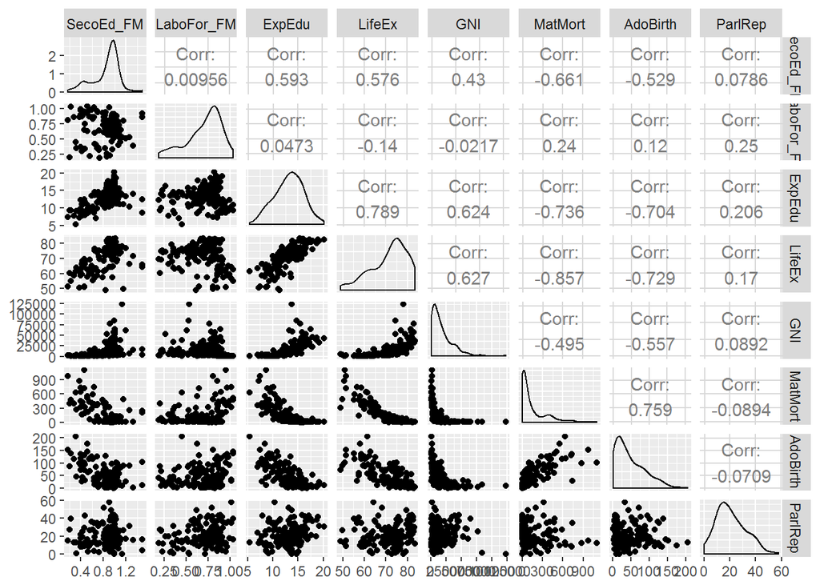

```r
library(ggplot2); library(GGally); library(corrplot)
ggpairs(human)
```

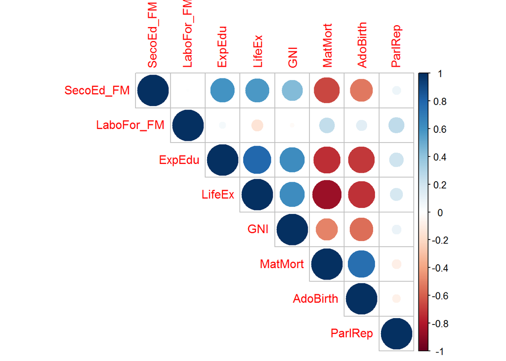

```r
cor(human)%>% corrplot(type = "upper")
```

### Principal Component Analysis (PCA)

Alright, first let’s perform PCA on the non-standardized data

```r
pca_human <- prcomp(human)
s <- summary(pca_human)
s
```

```
## Importance of components%s:
##                              PC1      PC2   PC3   PC4   PC5   PC6    PC7
## Standard deviation     1.854e+04 185.5219 25.19 11.45 3.766 1.566 0.1912
## Proportion of Variance 9.999e-01   0.0001  0.00  0.00 0.000 0.000 0.0000
## Cumulative Proportion  9.999e-01   1.0000  1.00  1.00 1.000 1.000 1.0000
##                           PC8
## Standard deviation     0.1591
## Proportion of Variance 0.0000
## Cumulative Proportion  1.0000
```

```r
pca_pr <- round(1*s$importance[2, ]*100, digits = 1)
pca_pr
```

```
## PC1 PC2 PC3 PC4 PC5 PC6 PC7 PC8
## 100   0   0   0   0   0   0   0
```

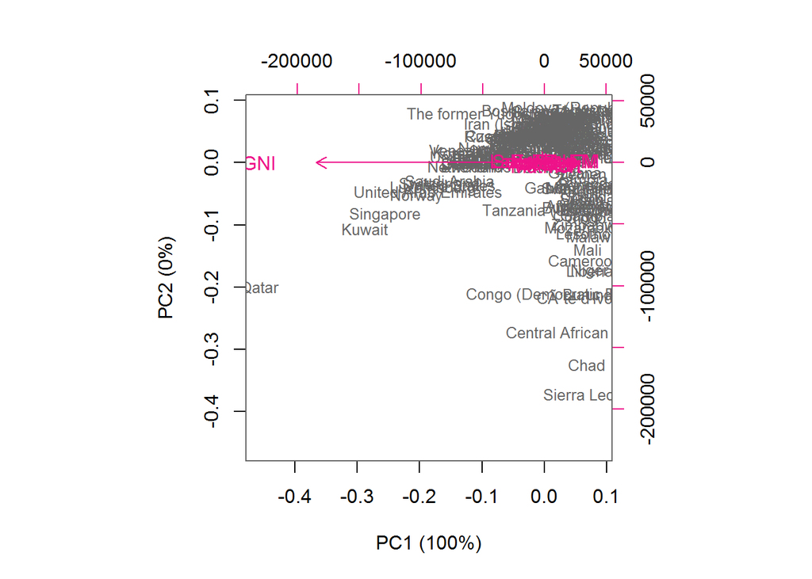

```r
pc_lab<-paste0(names(pca_pr), " (", pca_pr, "%)")
biplot(pca_human, cex = c(0.8, 1), col = c("grey40", "deeppink2"), xlab = pc_lab[1], ylab = pc_lab[2])
```

And next with the standardized data

```r
human_std <- scale(human)
pca_humanstd <- prcomp(human_std)
s <- summary(pca_humanstd)
s
```

```
## Importance of components%s:
##                           PC1    PC2     PC3     PC4     PC5     PC6
## Standard deviation     2.0708 1.1397 0.87505 0.77886 0.66196 0.53631
## Proportion of Variance 0.5361 0.1624 0.09571 0.07583 0.05477 0.03595
## Cumulative Proportion  0.5361 0.6984 0.79413 0.86996 0.92473 0.96069
##                            PC7     PC8
## Standard deviation     0.45900 0.32224
## Proportion of Variance 0.02634 0.01298
## Cumulative Proportion  0.98702 1.00000
```

```r
pca_pr <- round(1*s$importance[2, ]*100, digits = 1)
pca_pr
```

```
##  PC1  PC2  PC3  PC4  PC5  PC6  PC7  PC8
## 53.6 16.2  9.6  7.6  5.5  3.6  2.6  1.3
```

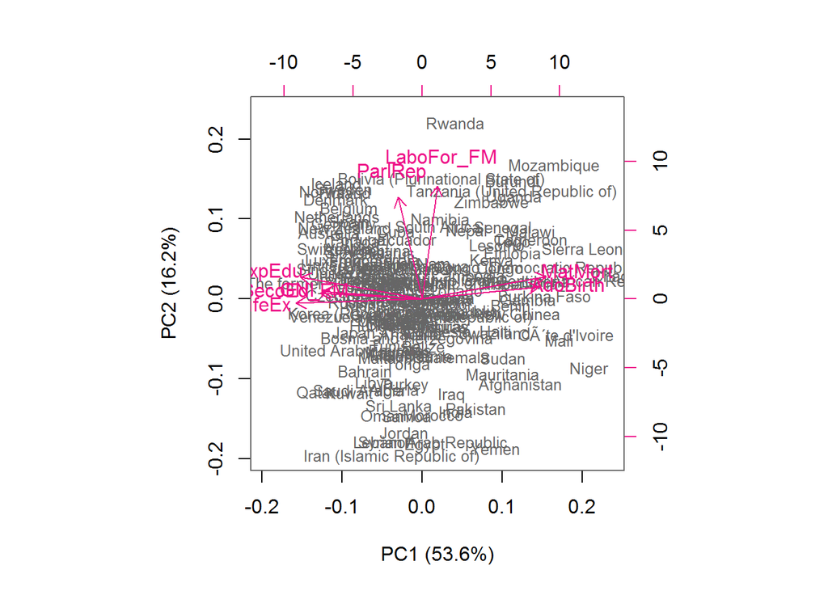

```r
pc_lab<-paste0(names(pca_pr), " (", pca_pr, "%)")
biplot(pca_humanstd, cex = c(0.8, 1), col = c("grey40", "deeppink2"), xlab = pc_lab[1], ylab = pc_lab[2])
```

Clearly the latter figure is more readable than the previous. There were also some zero-length arrows in the PCA of non-standardized data, which led to them being left out completely. The standardization changed the data so that PCA is able to take into account all data there is.

The latter PCA shows that there are differences between variables and their relationships to the principal components. This can be seen by looking at the arrows and their angles towards each other and to the PCs. In the first figure it looks like there are no differences at all, as all the arrows have no angle with the PCs. The smaller the angle is, whether between the different arrows, or the arrow and PC axis, the higher positive correlation there is. So we see that female parliament representation and female/male labour force ratio have quite small correlations with all other variables and also with PC1.

### FactomineR and MCA

```r
library(FactoMineR);library(tidyr)
data("tea")
str(tea)
```

```
## 'data.frame':    300 obs. of  36 variables:
##  $ breakfast       : Factor w/ 2 levels "breakfast","Not.breakfast": 1 1 2 2 1 2 1 2 1 1 ...
##  $ tea.time        : Factor w/ 2 levels "Not.tea time",..: 1 1 2 1 1 1 2 2 2 1 ...
##  $ evening         : Factor w/ 2 levels "evening","Not.evening": 2 2 1 2 1 2 2 1 2 1 ...
##  $ lunch           : Factor w/ 2 levels "lunch","Not.lunch": 2 2 2 2 2 2 2 2 2 2 ...
##  $ dinner          : Factor w/ 2 levels "dinner","Not.dinner": 2 2 1 1 2 1 2 2 2 2 ...
##  $ always          : Factor w/ 2 levels "always","Not.always": 2 2 2 2 1 2 2 2 2 2 ...
##  $ home            : Factor w/ 2 levels "home","Not.home": 1 1 1 1 1 1 1 1 1 1 ...
##  $ work            : Factor w/ 2 levels "Not.work","work": 1 1 2 1 1 1 1 1 1 1 ...
##  $ tearoom         : Factor w/ 2 levels "Not.tearoom",..: 1 1 1 1 1 1 1 1 1 2 ...
##  $ friends         : Factor w/ 2 levels "friends","Not.friends": 2 2 1 2 2 2 1 2 2 2 ...
##  $ resto           : Factor w/ 2 levels "Not.resto","resto": 1 1 2 1 1 1 1 1 1 1 ...
##  $ pub             : Factor w/ 2 levels "Not.pub","pub": 1 1 1 1 1 1 1 1 1 1 ...
##  $ Tea             : Factor w/ 3 levels "black","Earl Grey",..: 1 1 2 2 2 2 2 1 2 1 ...
##  $ How             : Factor w/ 4 levels "alone","lemon",..: 1 3 1 1 1 1 1 3 3 1 ...
```

[output cut: 22 more lines]

```r
dim
```

```
## function (x)  .Primitive("dim")
```

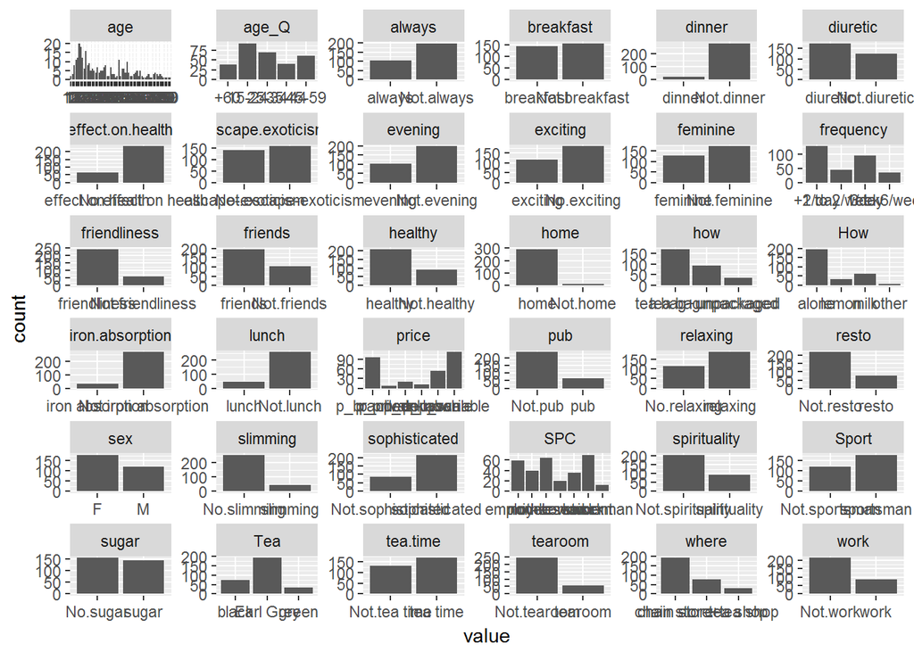

```r
gather(tea) %>% ggplot(aes(value)) + facet_wrap("key", scales = "free") + geom_bar()
```

The figure is a bit messy, but unfortunately I don’t have time now to try to make it clearer. It doesn’t work the same as in datacamp, probably because I have all the variables left here instead of choosing a smaller dataset like in the datacamp examples. Next I will, anyway perform mutliple correspondence analysis on the whole dataset. Let’s see what that’ll look like..

```r
library(stringr)
```

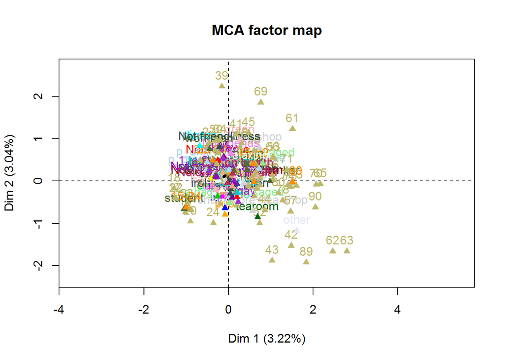

```r
tea$age <- str_replace(tea$age, pattern=",", replace ="") %>% as.factor() #this changes variable age to a factor, since all variables need to be factors
mca <- MCA(tea, graph = FALSE)
plot(mca, invisible=c("ind"), habillage = "quali")
```

```r
summary(mca)
```

```
##
## Call:
## MCA(X = tea, graph = FALSE)
##
##
## Eigenvalues
##                        Dim.1   Dim.2   Dim.3   Dim.4   Dim.5   Dim.6
## Variance               0.102   0.096   0.085   0.076   0.066   0.065
## % of var.              3.217   3.038   2.686   2.413   2.083   2.063
## Cumulative % of var.   3.217   6.255   8.941  11.353  13.436  15.499
##                        Dim.7   Dim.8   Dim.9  Dim.10  Dim.11  Dim.12
## Variance               0.063   0.060   0.056   0.055   0.052   0.050
## % of var.              2.003   1.890   1.755   1.732   1.651   1.594
## Cumulative % of var.  17.502  19.392  21.147  22.879  24.530  26.124
##                       Dim.13  Dim.14  Dim.15  Dim.16  Dim.17  Dim.18
## Variance               0.049   0.047   0.047   0.046   0.044   0.044
## % of var.              1.542   1.496   1.481   1.444   1.403   1.376
## Cumulative % of var.  27.666  29.162  30.643  32.088  33.491  34.867
##                       Dim.19  Dim.20  Dim.21  Dim.22  Dim.23  Dim.24
## Variance               0.043   0.041   0.040   0.040   0.039   0.039
## % of var.              1.349   1.297   1.266   1.250   1.221   1.218
## Cumulative % of var.  36.216  37.512  38.778  40.028  41.249  42.467
##                       Dim.25  Dim.26  Dim.27  Dim.28  Dim.29  Dim.30
## Variance               0.037   0.037   0.036   0.036   0.035   0.035
## % of var.              1.181   1.155   1.146   1.142   1.115   1.104
## Cumulative % of var.  43.648  44.802  45.948  47.090  48.206  49.310
##                       Dim.31  Dim.32  Dim.33  Dim.34  Dim.35  Dim.36
## Variance               0.035   0.033   0.033   0.033   0.033   0.032
## % of var.              1.090   1.053   1.042   1.038   1.026   1.001
## Cumulative % of var.  50.400  51.452  52.494  53.533  54.559  55.560
##                       Dim.37  Dim.38  Dim.39  Dim.40  Dim.41  Dim.42
## Variance               0.031   0.031   0.030   0.030   0.030   0.030
## % of var.              0.985   0.978   0.957   0.951   0.943   0.940
## Cumulative % of var.  56.545  57.523  58.480  59.430  60.374  61.314
##                       Dim.43  Dim.44  Dim.45  Dim.46  Dim.47  Dim.48
## Variance               0.030   0.029   0.029   0.029   0.029   0.029
## % of var.              0.935   0.922   0.920   0.915   0.909   0.906
## Cumulative % of var.  62.249  63.171  64.091  65.006  65.915  66.821
##                       Dim.49  Dim.50  Dim.51  Dim.52  Dim.53  Dim.54
## Variance               0.028   0.028   0.028   0.028   0.028   0.028
```

[output cut: 88 more lines]

```
## dinner        |  0.339  0.263  0.009  1.609 |
## Not.dinner    | -0.026  0.020  0.009 -1.609 |
##
## Categorical variables (eta2)
##                 Dim.1 Dim.2 Dim.3
## breakfast     | 0.007 0.014 0.002 |
## tea.time      | 0.050 0.185 0.000 |
## evening       | 0.034 0.071 0.043 |
## lunch         | 0.001 0.071 0.004 |
## dinner        | 0.035 0.051 0.009 |
## always        | 0.010 0.070 0.012 |
## home          | 0.007 0.019 0.012 |
## work          | 0.001 0.052 0.137 |
## tearoom       | 0.114 0.175 0.065 |
## friends       | 0.002 0.218 0.032 |
```